# Assignment 5

Bethany Riess

August 16, 2020

## Introduction

This analysis attempts to demonstrate the number of daily and total deaths amongst 3 different countries. The three contries chosen for this analysis were Germany, France, and Italy. The following information shows the daily and total death rates for each country.

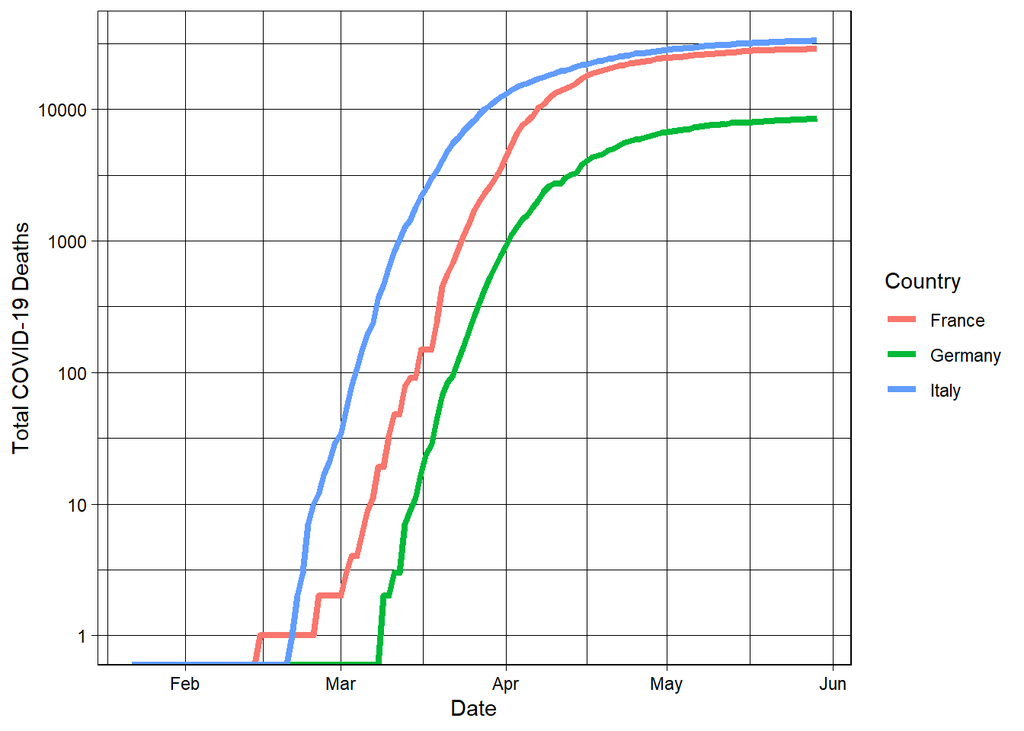

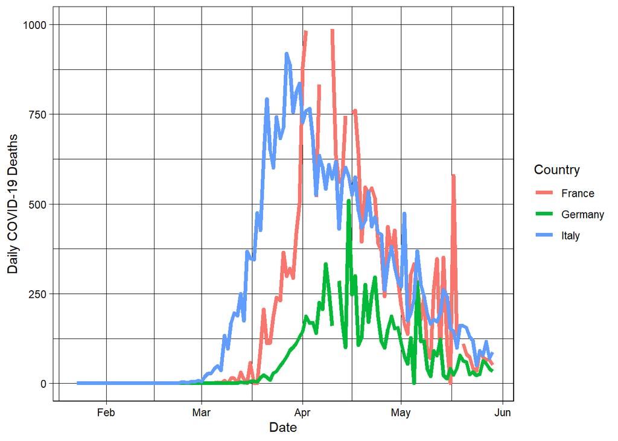

| Country | max(Daily_Deaths, na.rm = TRUE) |
| --- | --- |
| France | 1438 |
| Germany | 510 |
| Italy | 919 |

## Conclusion

Based on the information above, we can see that Italy has had the highest overall deaths generally throughout the Covid-19 pandemic compared to France and Germany. France has had the second highest amongst the three, and Germany has had the least. Germany has had consistently lower daily deaths than the other two countries, and France has had the least consistent amount of daily deaths. Overall, the total and daily deaths for Italy have been the worst, except for a few days for France. The maximum daily deaths for France was over 1400, while the maximum for Italy was not even 1000, even though Italy was still greater in deaths overall.

## Reference

Data Source  
China Data Lab, 2020, “Countries-Deaths.tab”, World COVID-19 Daily Cases with Basemap, https://doi.org/10.7910/DVN/L20LOT/FZLQRQ, *Harvard Dataverse*, V22, UNF:6:AntG1aQ3uPjWCuJZ5P2uEA== [fileUNF]